# Data (1)

Project #2: Analysis of Smoking and Health Data Introduction

In this project, we explore a dataset that contains health-related information, including smoking habits, heart rate, and cholesterol levels, among others. By analyzing this data, we aim to uncover insights into the health impacts of smoking and how they vary by age, gender, and other factors.

We have a few objectives for this project -To understand the health implications of smoking through various indicators. -To demonstrate data preprocessing, analysis, and visualization skills using Pandas and Matplotlib. -To communicate findings in a clear, understandable manner for public sharing.

-Data Acquisition

The dataset we used in this project is smoking_health_data_final.csv, which includes data on individuals' smoking status, age, gender, heart rate, blood pressure, daily cigarette consumption, and cholesterol levels.

First, we'll handle missing values and extract relevant features from the existing data.

```python
# Importing necessary libraries
import pandas as pd
import numpy as np
import matplotlib.pyplot as plt

# Load the data
data = pd.read_csv('smoking_health_data_final.csv')

# Fill missing values
data['cigs_per_day'] = data['cigs_per_day'].fillna(data['cigs_per_day'].mean())
data['chol'] = data['chol'].fillna(data['chol'].mean())

# Split blood pressure into systolic and diastolic
data[['systolic_bp', 'diastolic_bp']] = data['blood_pressure'].str.split('/', expand=True).astype(float)
```

1. Age Distribution of Smokers vs. Non-Smokers

We begin by examining how the age distribution differs between smokers and non-smokers for exploratary data analysis and visualization.

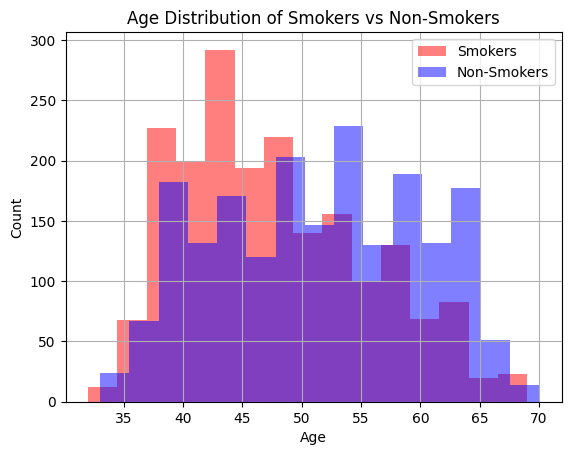

```python
# Plotting age distribution
fig, ax = plt.subplots()
data[data['current_smoker'] == 'yes']['age'].hist(alpha=0.5, color='red', bins=15, label='Smokers')
data[data['current_smoker'] == 'no']['age'].hist(alpha=0.5, color='blue', bins=15, label='Non-Smokers')
ax.set_xlabel('Age')
ax.set_ylabel('Count')
ax.set_title('Age Distribution of Smokers vs Non-Smokers')
ax.legend()
plt.show()
```

1. Gender and Smoking Habits

Next, we explore the proportion of smokers among males and females.

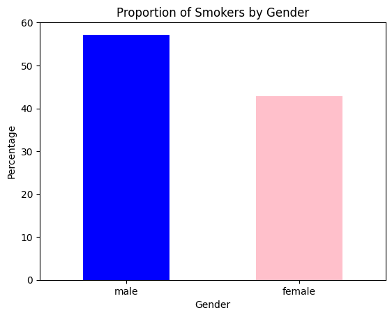

```python
# Analyzing the proportion of smokers by gender
smoker_gender = data[data['current_smoker'] == 'yes']['sex'].value_counts(normalize=True) * 100
smoker_gender.plot(kind='bar', color=['blue', 'pink'])
plt.title('Proportion of Smokers by Gender')
plt.xlabel('Gender')
plt.ylabel('Percentage')
plt.xticks(rotation=0)
plt.show()
```

1. Average Cigarettes Per Day

```python
# Computing the average number of cigarettes smoked per day by smokers
avg_cigs_per_day = data[data['current_smoker'] == 'yes']['cigs_per_day'].mean()
print(f'Average cigarettes per day among smokers: {avg_cigs_per_day:.2f}')
```

```
Average cigarettes per day among smokers: 18.51
```

This question helps us answer and understand smoking habits of smokers and how many cigarettes per day they might be smoking so that we can plan better.

1. Heart Rate Comparison Between Smokers and Non-Smokers

```python
# Comparing the average heart rate between smokers and non-smokers
avg_hr_smokers = data[data['current_smoker'] == 'yes']['heart_rate'].mean()
avg_hr_nonsmokers = data[data['current_smoker'] == 'no']['heart_rate'].mean()
print(f'Average heart rate of smokers: {avg_hr_smokers:.2f}')
print(f'Average heart rate of non-smokers: {avg_hr_nonsmokers:.2f}')
```

```
Average heart rate of smokers: 76.38
Average heart rate of non-smokers: 75.01
```

1. Impact of Smoking on Blood Pressure Variability

```
Standard deviation of systolic blood pressure among smokers: 20.30
Standard deviation of systolic blood pressure among non-smokers: 23.13
```

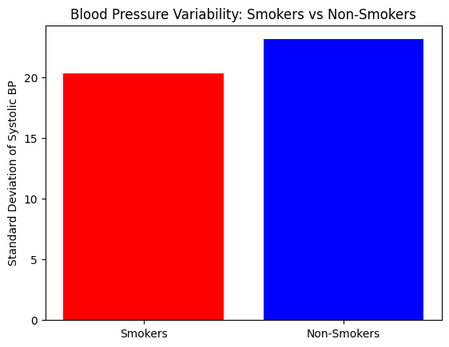

```python
# Calculating the standard deviation of systolic blood pressure for smokers and non-smokers
bp_std_smokers = data[data['current_smoker'] == 'yes']['systolic_bp'].std()
bp_std_nonsmokers = data[data['current_smoker'] == 'no']['systolic_bp'].std()

# Displaying the results
print(f'Standard deviation of systolic blood pressure among smokers: {bp_std_smokers:.2f}')
print(f'Standard deviation of systolic blood pressure among non-smokers: {bp_std_nonsmokers:.2f}')

# Plotting the results for visual comparison
labels = ['Smokers', 'Non-Smokers']
values = [bp_std_smokers, bp_std_nonsmokers]
plt.bar(labels, values, color=['red', 'blue'])
plt.ylabel('Standard Deviation of Systolic BP')
plt.title('Blood Pressure Variability: Smokers vs Non-Smokers')
plt.show()
```

This analysis calculates the standard deviation of systolic blood pressure for both smokers and non-smokers. A higher standard deviation indicates greater variability in blood pressure, which can be linked to increased cardiovascular risk. The bar chart visually contrasts these groups to highlight potential health impacts of smoking on blood pressure stability.

1. Blood Pressure Categories

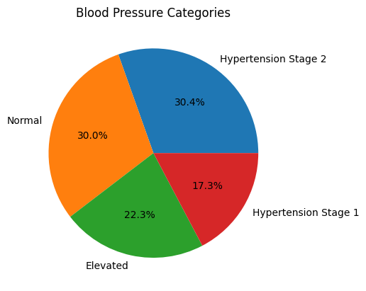

```python
# Categorizing and visualizing blood pressure levels
def bp_category(systolic):
    if systolic < 120:
        return 'Normal'
    elif systolic < 130:
        return 'Elevated'
    elif systolic < 140:
        return 'Hypertension Stage 1'
    else:
        return 'Hypertension Stage 2'
data['bp_category'] = data['systolic_bp'].apply(bp_category)
bp_counts = data['bp_category'].value_counts()
bp_counts.plot(kind='pie', autopct='%1.1f%%')
plt.title('Blood Pressure Categories')
plt.ylabel('')
plt.show()
```

This pie chart categorizes individuals into different blood pressure groups, helping provide us a clear visual of the population's blood pressure distribution.

We performed various tasks importing the data, exploring and understanding the nature of data, and cleaning and preparing the data according to our issue so that it can be used to answer the question by analyzing the data.